# Association between dependent measures and T-500 self-reported in Mood/Anxiety

Saeid Parvandeh

June 2017

Analysis description: T-500 self-reported data base consists of many different coded claim data related to each subject and capture only some elements clinical representation, here we measure other benefits from narrative discharge summaries also called lifechart narrative note that is a short story of subject’s life. We used a Natural Language Processing method that aggregates words emotion with three scores, word with positive valence (between 0-1), word with negative valence (between -1-0), and degree of word subjectivity (between 0-1). In this analysis study, we compute three scores for each subject and investigate the association between the measured scores and T-500 data, based on mood/axiety group, step-by-step.

Number of subjects in mood/axiety.

```
## [1] 194
```

We start with an example: consider the following a random subject narrative note.

```
## A random narrative note:
##
##  2nd to oldest of four girls born to her parents; raised by her mother and father. Father was a pastor to a non-denominational church (belief system similar to the Pentecostal church). Starting in subject's early years, she was very quiet and shy in school- had friendships and was involved in and…
```

The following adjective words are selected from the above narrative note with an aggregated subjectivity score, subjectivity score normalized with all adjective words in this narrative note and subjectivity score nomalized with total words in this narrative note.

```
## Subjectivity Score: 6
## Subjectivity score-normalized by total adjective words: 0.25
##
## Subjectivity score-normalized by total words: 0.02112676
##
## Adjective Words and their score: ['nondenominational', 0.0, 'similar', 0.4, 'early', 0.3, 'quiet', 0.3333333333333333, 'extracurricular', 0.0, 'uncomfortable', 1.0, 'extroverted', 0.0, 'afraid', 0.9, 'teachingsubject', 0.0, 'inner', 0.16666666666666666, '1st', 0.0, 'depressive', 0.0, 'indifferent…
```

The following words with positive valence are selected from the above narrative note with an aggregated positive score, positive score normalized with all positive valence words in this narrative note and positive score normalized with total words in this narrative note.

```
## Positive Score: 0.1
## Positive score-normalized by total adjective words 0.1 Positive score-normalized by total words: 0.000352113
##
## Words with positive valence and their score: ['early', 0.1]
```

The following words with negative valence are selected from the above narrative note with an aggregated negative score, negative score normalized with all negative valence words in this narrative note and negative score normalized with total words in this narrative note.

```
## Negative Score: -2.3375
## Negative score-normalized by total adjective words: -0.4675 Negative score-normalized by total words: -0.008230634
##
## Words with negative valence and their score: ['uncomfortable', -0.5, 'afraid', -0.6, 'little', -0.1875, 'worthless', -0.8, 'anxious', -0.25]
```

In following histogram plots show the frequency of total number of words and adjective words:

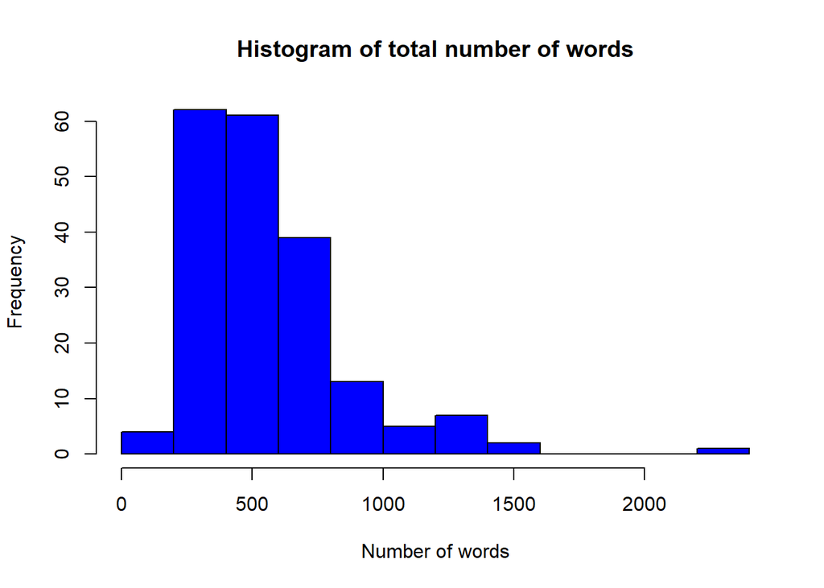

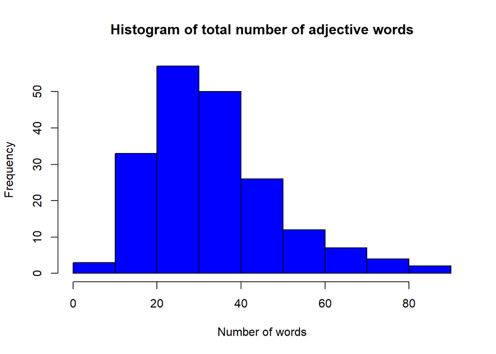

As we saw in above example, scores are nomalized by total words and total adjective words, and we are interested to choose those scores that more negatively correlated in positive scores and negative scores. Below, we check the correlation of three different types of dependend measure scores:

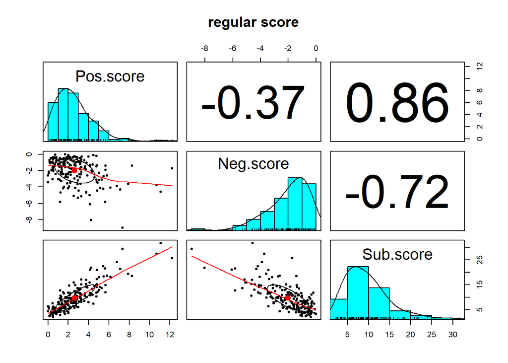

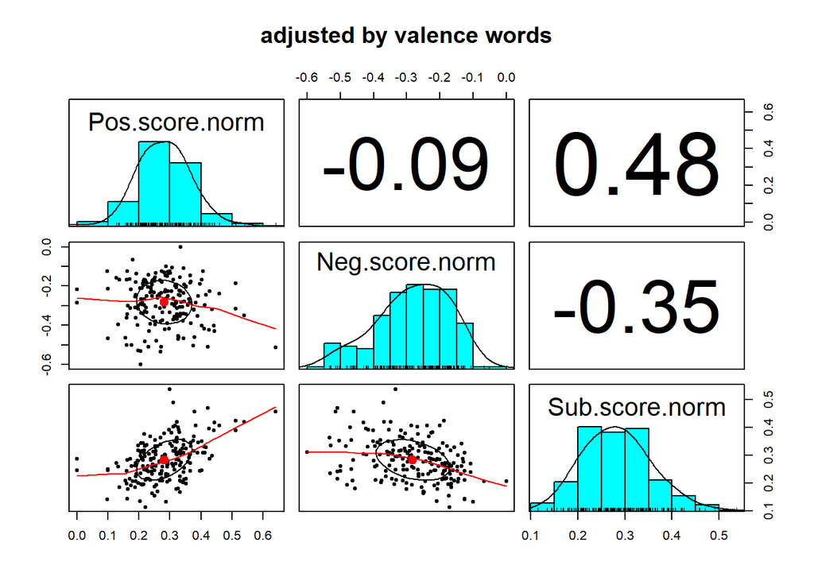

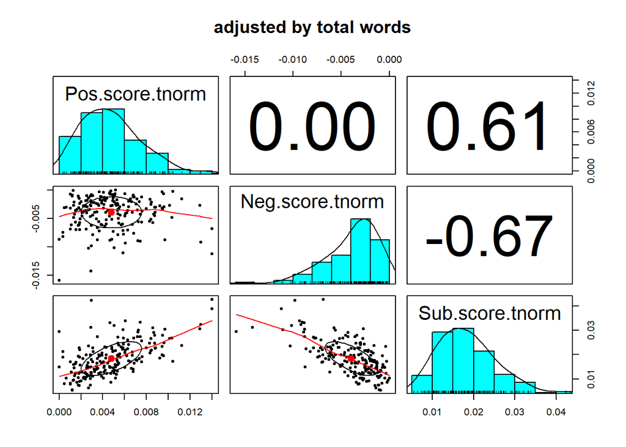

It looks like that the regular scores without normalization is better choice. Thus, we compute the regular scores for all subjects independently. The following plots show the histogram of three different scores:

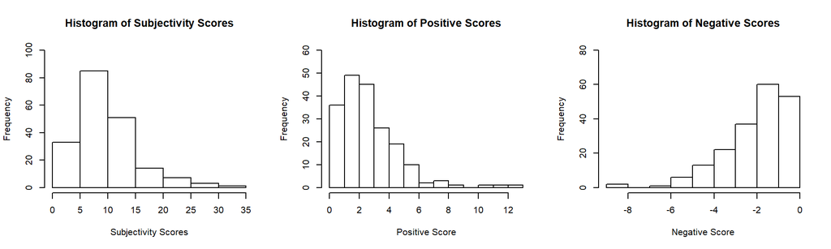

Association of total number of words and adjective words with PHQ, OASIS, AND CTQ

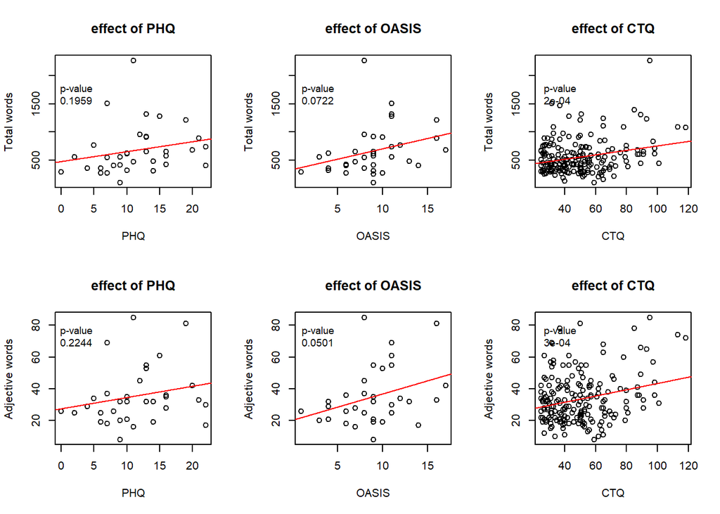

Extract Age, Gender, Income, and Education

Determine the degree to which socio-demographic characteristics effect the dependent measures

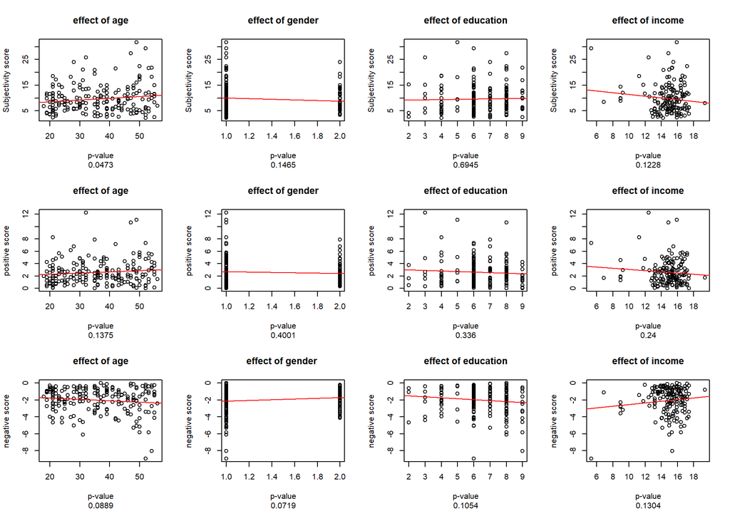

Determine the relationship with respect to the following trait variables: (PANAS-X, BIF, Symptom scales PHQ-9)

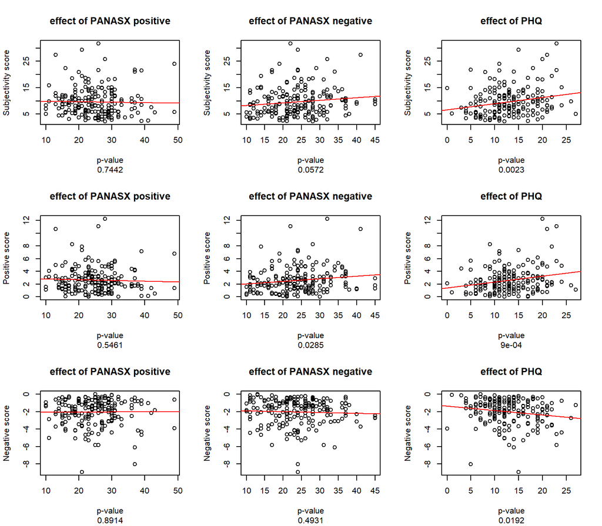

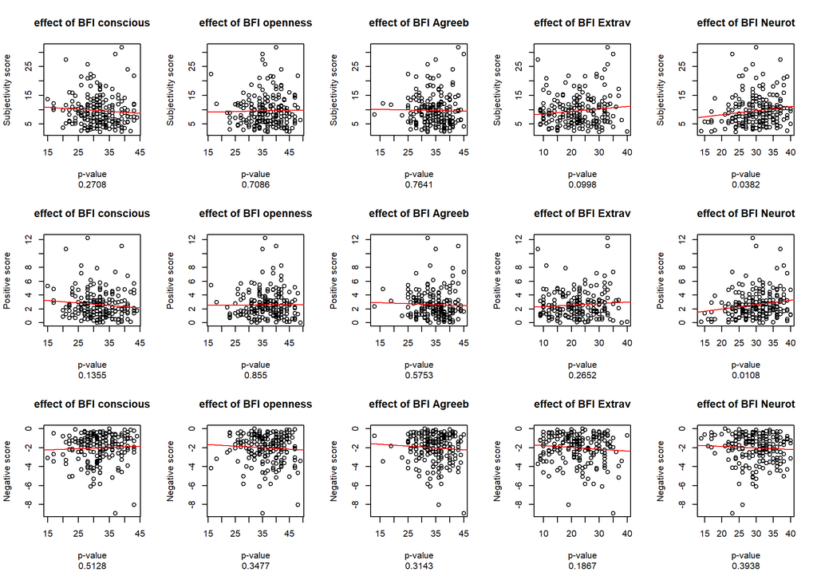

Determine the relationship with respect to the following trait variables: (Symptom scales OASIS), PROMIS (anxiety, depression, anger), Interviewers)

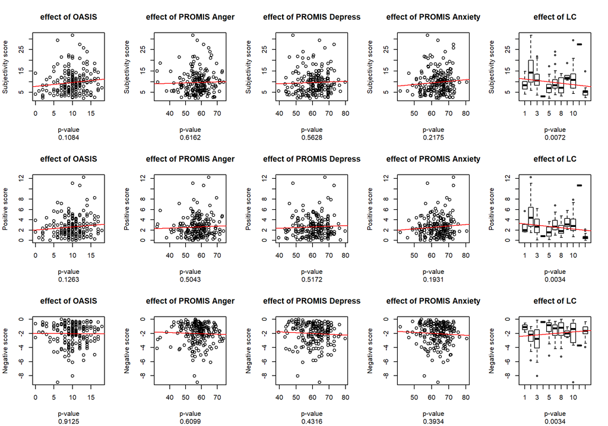

Determine mediating influences (CTQ, TEC)on dependent measured scores

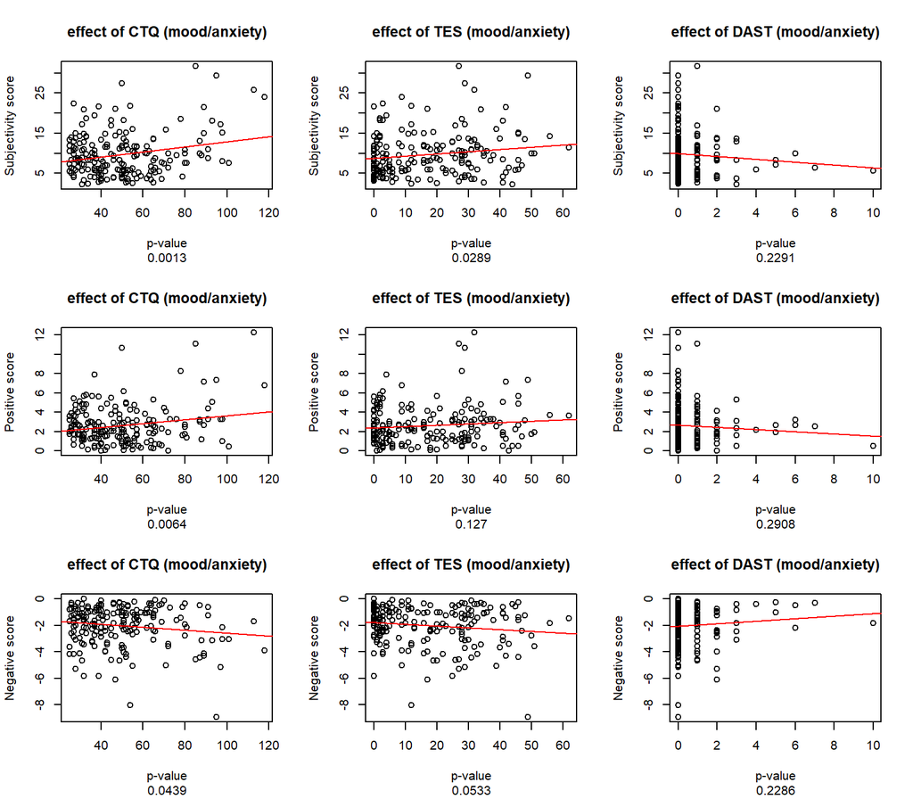

Severity of disorders between interviewers (PHQ, OASIS) if patients’ score is the same, are the notes in the same lenghth as well?

```
##     OASIS PHQ Total_words Interviewer
## 109    15  27         209       mcole
## 83     14  26         424 dcrittenden
## 75      7  24         751    lparsley
## 154     8  24         725 dcrittenden
## 33     10  23        1390     bsawyer
## 89      9  23         973     bsawyer
## 18      9  22         576     lkinyon
## 50     18  22         349    lparsley
## 91     11  22         375    lparsley
## 134    14  22        1470      pfeins
## 8       2  21         434     lkinyon
## 121    12  21         307       mcole
## 128    12  21        1209    sgregory
## 138    10  21         718 dcrittenden
## 156    14  21         741     lkinyon
```

```
##     OASIS PHQ Total_words Interviewer
## 50     18  22         349    lparsley
## 17     17  17         891     lkinyon
## 45     17  19         545 dcrittenden
## 85     17  15         446     lkinyon
## 176    17  21         894      pfeins
## 186    17  15         681     lkinyon
## 27     16   9        1093     bsawyer
## 44     16  20         644     bsawyer
## 65     16  12         699 dcrittenden
## 78     16   9         772     bsawyer
## 108    16   8         161      spetty
## 132    16  19         532 dcrittenden
## 39     15  14         843 dcrittenden
## 57     15   7         300    lparsley
## 69     15   6         425 dcrittenden
```

```
##     OASIS PHQ Total_words Interviewer
## 9      13  13         409 dcrittenden
## 17     17  17         891     lkinyon
## 68     11  11         478     lkinyon
## 81     10  10         463 dcrittenden
## 82     13  13         377    lparsley
## 118     7   7         322       mcole
## 126    13  13        1244     lkinyon
## 130     9   9         429       mcole
## 141     5   5         871      bragle
## 162     8   8         372 dcrittenden
## 179    10  10         763     mfoster
```

Concatenate all the valence words, and find the frequency of each word

```
## valence_words
##                 subject       first        high         due         old
##       15130         699         641         534         528         455
##       other       daily  elementary          th         new    pregnant
##         330         235         196         196         193         190
##     abusive        able         few        last   difficult       happy
##         186         172         168         168         165         154
##      social     several        good      second       close     anxious
##         146         143         135         135         125         120
##      middle        same         own   different        full        much
##         118         118         114         110         104         104
##      public    maternal     current         bad      sexual       major
##         102          91          84          83          83          79
##    multiple    physical    positive   depressed   alcoholic         low
##          79          76          73          72          71          70
##    negative      active        many significant        only       small
##          67          66          66          66          64          62
##       young       joint        past     primary       sober      unable
##          62          60          58          58          58          58
##      normal    paternal          rd          st       early  depressive
##          57          57          57          57          56          53
##        hard       moved     married     overall        meth      mental
##          53          52          51          51          50          48
##  biological       drunk    previous     unhappy     medical participant
##          47          46          46          46          45          45
##         sad        long      entire    military    divorced       large
##          45          44          42          42          40          40
##      little     private       angry     certain       xweek       great
##          40          40          38          38          37          36
##     outside        numb  interested     special    suicidal      online
##          36          35          34          34          34          33
##       wrong   emotional     healthy        sick     enjoyed      foster
##          33          32          32          32          31          31
##    homeless      verbal      afraid       clean
##          31          31          30          30
```